# 5243_HW1

Yang Chen, YC3335

#### Import library

```r
library(tidyverse)
library(tidytext)
library(DT)
library(scales)
```

```r
library(wordcloud2)
library(gridExtra)
library(ngram)
library(dplyr)
library(janeaustenr)
library(tidytext)
library(SnowballC)
library(wordcloud)
library(koRpus)
```

### Load the processed text data along with demographic information on contributors

We use the processed data for our analysis and combine it with the demographic information available.

```r
hm_data <- read_csv("../output/processed_moments.csv")

urlfile<-'https://raw.githubusercontent.com/rit-public/HappyDB/master/happydb/data/demographic.csv'
demo_data <- read_csv(urlfile)
```

### Combine both the data sets and keep the required columns for analysis

We select a subset of the data that satisfies specific row conditions.

```r
hm_data <- hm_data %>%
  inner_join(demo_data, by = "wid") %>%
  select(wid,
         original_hm,
         gender,
         marital,
         parenthood,
         reflection_period,
         age,
         country,
         ground_truth_category,
         text) %>%
  mutate(count = sapply(hm_data$text, wordcount)) %>%
  filter(gender %in% c("m", "f")) %>%
  filter(marital %in% c("single", "married")) %>%
  filter(parenthood %in% c("n", "y")) %>%
  filter(reflection_period %in% c("24h", "3m")) %>%
  mutate(reflection_period = fct_recode(reflection_period,
                                        months_3 = "3m", hours_24 = "24h"))
```

### Create a bag of words using the text data

```r
bag_of_words <-  hm_data %>%
  unnest_tokens(word, text)

word_count_only <- bag_of_words %>%
  count(word, sort = TRUE)


word_count <- bag_of_words %>%
  count(wid,word,gender,marital,parenthood,reflection_period,country, sort = TRUE)
```

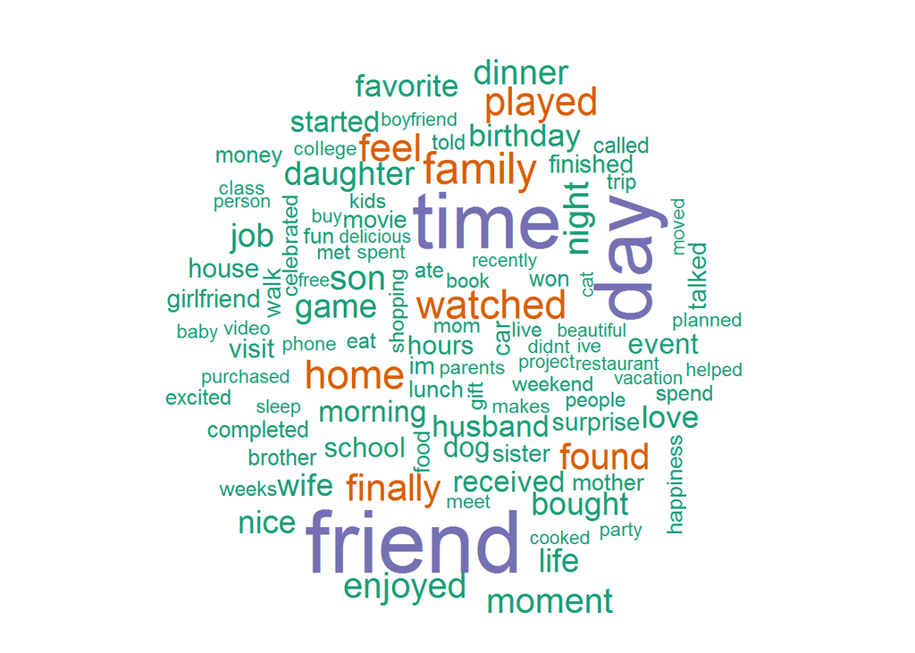

```r
wordcloud(word_count_only$word, word_count_only$n, max.words=100, colors=brewer.pal(1, "Dark2"))
```

# Someone might argue that in this word cloud we have day, night, morning that take no meaning and we have words ‘bought’ and ‘buy’ appear in the word cloud but they mean the same. Therefore we firstly need to first do the lemmatization to avoid different past tense and then we need to use tf-idf to eliminate the common words like ‘morning’ and etc.

```r
library(textstem)
bag_of_words$word=lemmatize_words(bag_of_words$word)
word_count_lemm <- bag_of_words %>%
  count(word, sort = TRUE)

library(tm)
```

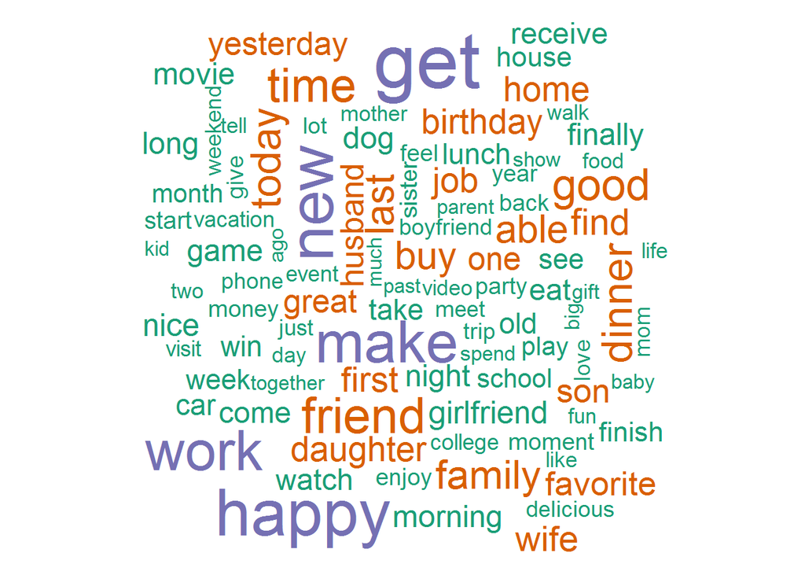

```r
hm_corpus <- VCorpus(VectorSource(hm_data$original_hm))
hm_corpus = tm_map(hm_corpus, content_transformer(tolower))
hm_corpus = tm_map(hm_corpus, removeNumbers)
hm_corpus = tm_map(hm_corpus, removePunctuation)
hm_corpus = tm_map(hm_corpus, removeWords, c("the", "and",'day', stopwords("english")))
hm_corpus =  tm_map(hm_corpus, stripWhitespace)


hm_tfidf <- DocumentTermMatrix(hm_corpus, control = list(weighting = weightTfIdf))
hm_tfidf = removeSparseTerms(hm_tfidf, 0.99)

freq = data.frame(sort(colSums(as.matrix(hm_tfidf)), decreasing=TRUE))
df=data.frame(lemm_words=lemmatize_words(rownames(freq)),score=freq[,1])
df_new=df[!duplicated(df$lemm_words), ]
wordcloud(df_new$lemm_words, df_new$score, max.words=100, colors=brewer.pal(3, "Dark2"))
```

#Now the word cloud emphasis looks better than the previously, ‘friend’ might be less relative important, while people prefer to tell their happy moment with past experience especially from yesterday. Then we need to analyze the time period influence people

```r
hm_words_time <- word_count %>%
  bind_tf_idf(word, wid, n)
hm_words_time
```

| wid | word | gender | marital | parenthood | reflection_period | country | n | tf | idf | tf_idf |
| --- | --- | --- | --- | --- | --- | --- | --- | --- | --- | --- |
| 53 | happiness | m | married | y | hours_24 | USA | 126 | 0.0673076923 | 3.0982889 | 0.208538673 |
| 817 | happiness | m | single | n | months_3 | USA | 121 | 0.0836212854 | 3.0982889 | 0.259082897 |
| 280 | life | m | married | y | hours_24 | IND | 100 | 0.0895255148 | 2.2154400 | 0.198338408 |
| 457 | happiness | m | single | y | months_3 | USA | 82 | 0.0457079153 | 3.0982889 | 0.141616325 |
| 954 | time | m | married | n | months_3 | IND | 77 | 0.0427777778 | 0.7835556 | 0.033518769 |
| 627 | happiness | m | married | n | months_3 | USA | 71 | 0.0795072788 | 3.0982889 | 0.246336516 |
| 954 | roti | m | married | n | months_3 | IND | 65 | 0.0361111111 | 6.6425871 | 0.239871200 |
| 1633 | happiness | m | married | y | months_3 | USA | 63 | 0.0785536160 | 3.0982889 | 0.243381793 |
| 120 | event | m | single | n | hours_24 | BGD | 56 | 0.0510483136 | 2.2172799 | 0.113188402 |
| 90 | happiness | m | married | y | hours_24 | USA | 51 | 0.0250245339 | 3.0982889 | 0.077533235 |

[output cut: 9990 more lines]

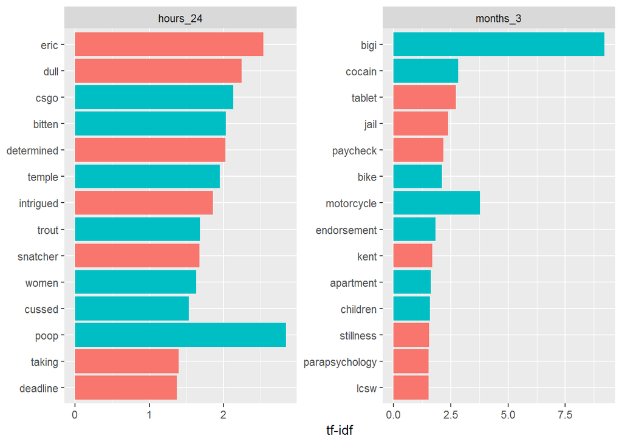

```r
hm_words_time <- hm_words_time[nchar(hm_words_time$word)>3,]

hm_words_time %>%
  group_by(reflection_period) %>%
  top_n(15, tf_idf) %>%
  ungroup() %>%
  mutate(word = reorder(word, tf_idf)) %>%
  ggplot(aes(word, tf_idf, fill = gender)) +
  geom_col(show.legend = FALSE) +
  labs(x = NULL, y = "tf-idf") +
  facet_wrap(~reflection_period, ncol = 2, scales = "free") +
  coord_flip()
```

#This is the reflection period with gender, and We notice in the happy moment there are some negative words like jail and etc. We analyze the sentiment by different age group here

```r
young_words <-  hm_data %>%
  filter(age >=17 & age<30) %>%
  unnest_tokens(word, text)

mid_age_words <- hm_data %>%
  filter(age >=30 & age<60) %>%
  unnest_tokens(word, text)

senior_words <- hm_data %>%
  filter(age >60) %>%
  unnest_tokens(word, text)

age_stage <- bind_rows(young_words %>%
                         inner_join(get_sentiments("bing")) %>%
                         count(word, sentiment) %>%
                         spread(sentiment, n, fill = 0) %>%
                         mutate(sentiment = positive - negative,method="young_adult"),
                       mid_age_words %>%
                         inner_join(get_sentiments("bing")) %>%
                         count(word, sentiment) %>%
                         spread(sentiment, n, fill = 0) %>%
                         mutate(sentiment = positive - negative,method="mid_aged"),
                       senior_words %>%
                         inner_join(get_sentiments("bing")) %>%
                         count(word, sentiment) %>%
                         spread(sentiment, n, fill = 0) %>%
                         mutate(sentiment = positive - negative,method="senior"))
```

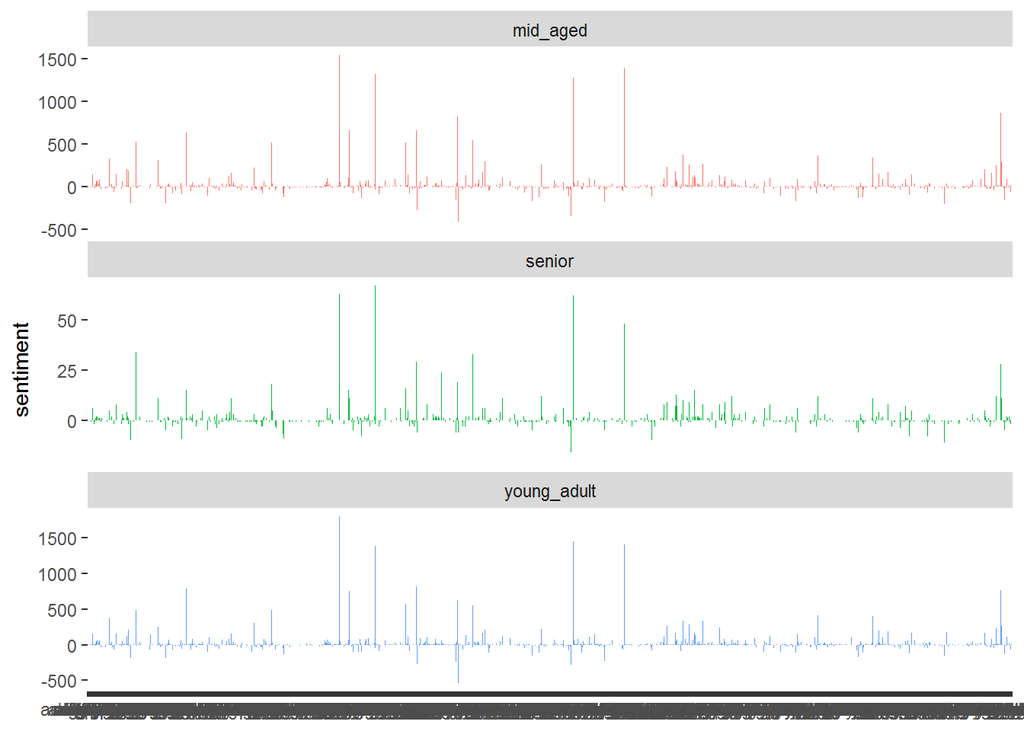

```r
age_stage %>%
  ggplot(aes(word, sentiment, fill = method)) +
  geom_col(show.legend = FALSE) +
  labs(x = NULL, y = "sentiment")+
  facet_wrap(~method, ncol = 1, scales = "free_y")
```

#Here we notice that senior has extremely low sentiment score, because senior have much more experience than young adult and mid-aged did. Therefore they have less motion violatility with their words.

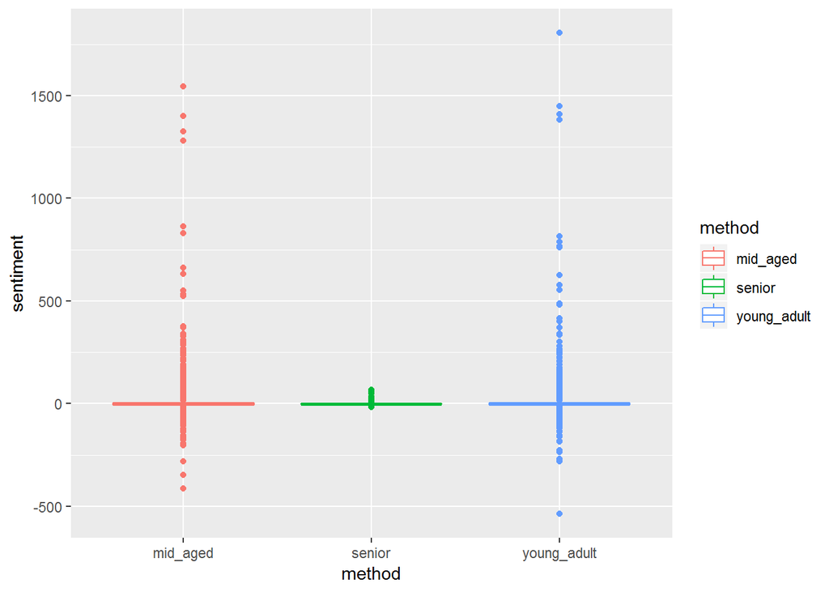

```r
ggplot(age_stage, aes(x = method, y = sentiment, color = method)) +
  geom_boxplot() # draw a boxplot for different age group
```

#By the boxplot we notice young adult have more extremley value than mid-aged for the positive and negative which make sense.

```r
library(reshape2)
```

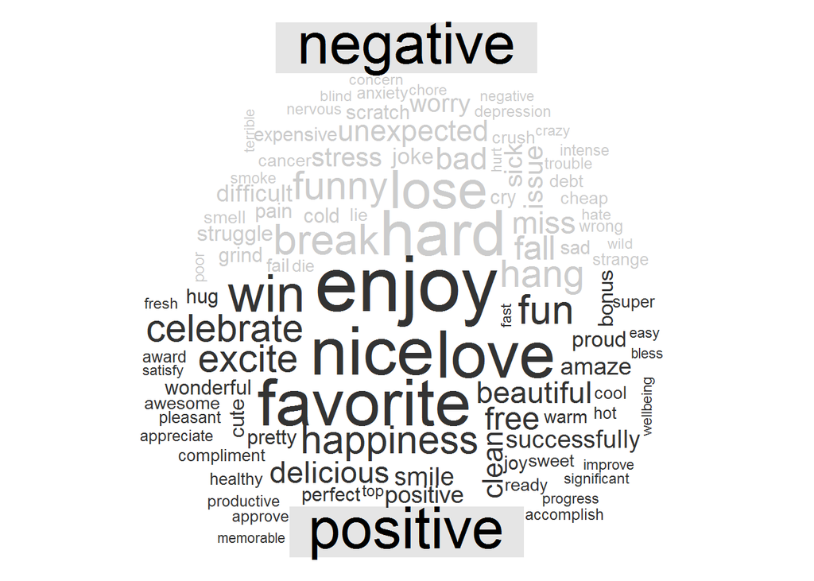

```r
bag_of_words %>%
  inner_join(get_sentiments("bing")) %>%
  count(word, sentiment, sort = TRUE) %>%
  acast(word ~ sentiment, value.var = "n", fill = 0) %>%
  comparison.cloud(colors = c("gray80", "gray20"),
                   max.words = 100)
```

#Although the blog are all about happinese moments, we believe that their words will definitely contian negative words, some negative words will be overcomed or solved by another negative word to be a postive phrases, some negatvie moment are past tense and should be happened previously which make authors feel happy today.

# We finished sentiment analysis and then we would like to analysis the phrase and bigram

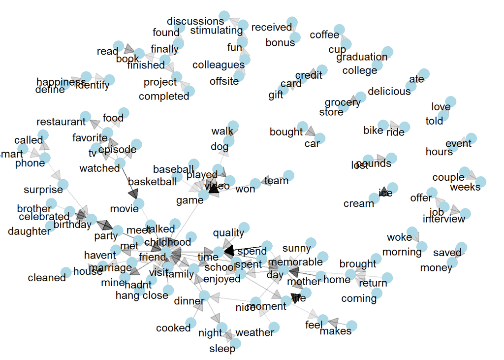

```r
library(igraph)
library(ggraph)

hm_bigrams <- hm_data %>%
  filter(count != 1) %>%
  unnest_tokens(bigram, text, token = "ngrams", n = 2)

bigram_counts <- hm_bigrams %>%
  separate(bigram, c("word1", "word2"), sep = " ") %>%
  count(word1, word2, sort = TRUE)

bigram_graph <- bigram_counts %>%
  filter(n > 100) %>%
  graph_from_data_frame()


set.seed(0)
a <- grid::arrow(type = "closed", length = unit(.15, "inches"))
ggraph(bigram_graph, layout = "fr") +
  geom_edge_link(aes(edge_alpha = n), show.legend = FALSE,
                 arrow = a, end_cap = circle(.07, 'inches')) +
  geom_node_point(color = "lightblue", size = 5) +
  geom_node_text(aes(label = name), vjust = 1, hjust = 1) +
  theme_void()
```

# In bigram, we believe friend is the most important word which consist the bigram phrase

# Finally we want to figure out the topic analysis we use LDA method

```r
library(topicmodels)
hm_lda_2 <- LDA(DocumentTermMatrix(hm_corpus), k = 2, control = list(seed = 2018))
```

# I firstly assign two topic to the happy moment corpus

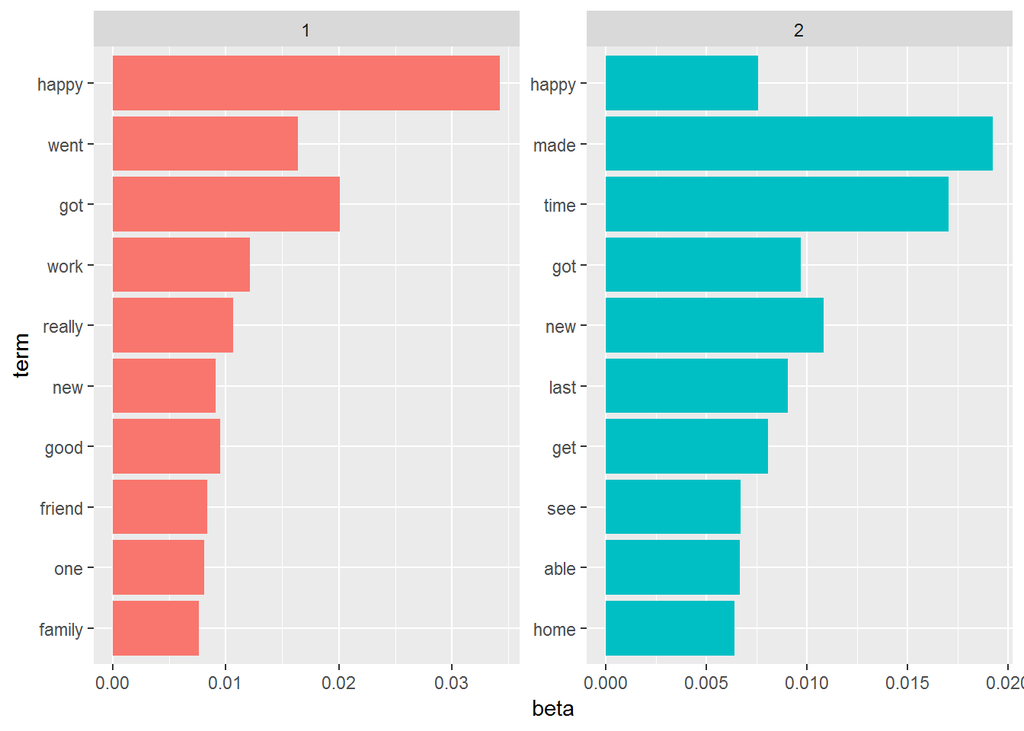

```r
text_topics <- tidy(hm_lda_2, matrix = "beta")

text_top_terms <- text_topics %>%
  group_by(topic) %>%
  top_n(10, beta) %>%
  ungroup() %>%
  arrange(topic, -beta)

text_top_terms %>%
  mutate(term = reorder(term, beta)) %>%
  ggplot(aes(term, beta, fill = factor(topic))) +
  geom_col(show.legend = FALSE) +
  facet_wrap(~ topic, scales = "free") +
  coord_flip()
```

# Then I try to find out the max probability difference between topic 1 and topic 2

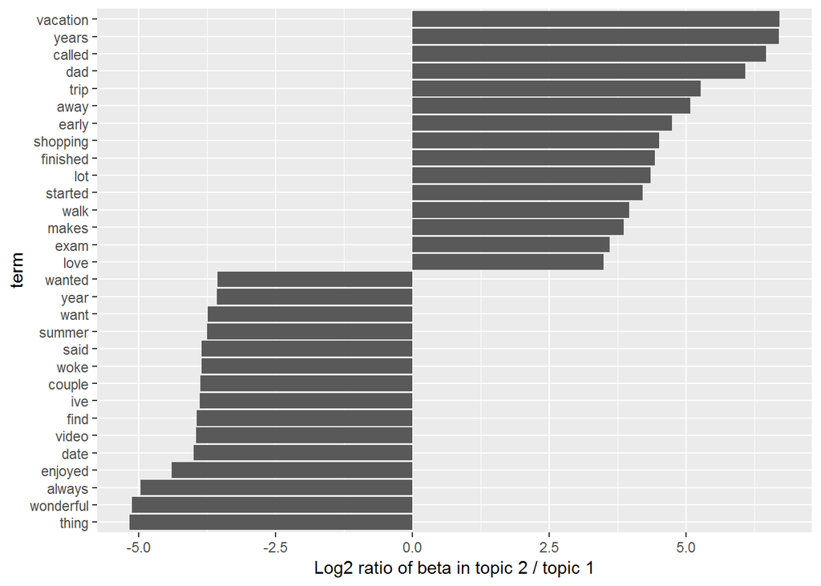

```r
beta_spread <- text_topics %>%
  mutate(topic = paste0("topic", topic)) %>%
  spread(topic, beta) %>%
  filter(topic1 > .001 | topic2 > .001) %>%
  mutate(log_ratio = log2(topic2 / topic1))

beta_spread %>%
  group_by(direction = log_ratio > 0) %>%
  top_n(15, abs(log_ratio)) %>%
  ungroup() %>%
  mutate(term = reorder(term, log_ratio)) %>%
  ggplot(aes(term, log_ratio)) +
  geom_col() +
  labs(y = "Log2 ratio of beta in topic 2 / topic 1") +
  coord_flip()
```

# Maybe topic 1 is regarding past 3 months experience and topic 2 is past 24 hours experience, but I did not see much difference and hard to recogize two topics boundary

# So I try to split to 6 topics. Assuming they belong to gender, marital, partnerhood,reflection_period, age and country

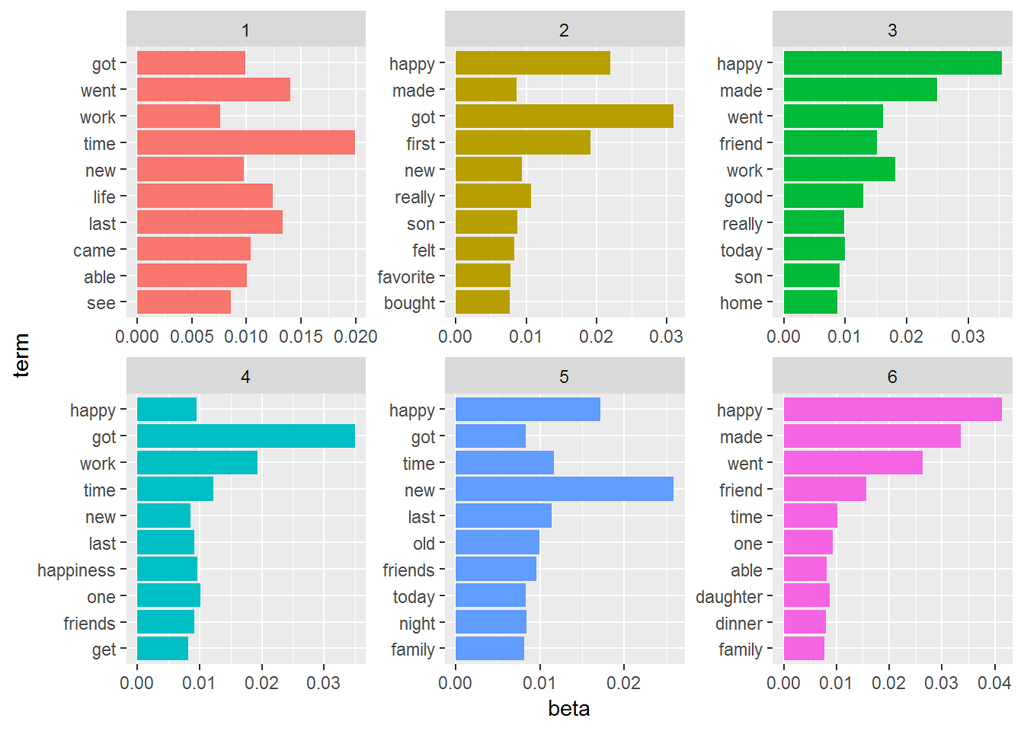

```r
hm_lda_6 <- LDA(DocumentTermMatrix(hm_corpus), k = 6, control = list(seed = 0))
text_topics1 <- tidy(hm_lda_6, matrix = "beta")
text_top_terms1 <- text_topics1 %>%
  group_by(topic) %>%
  top_n(10, beta) %>%
  ungroup() %>%
  arrange(topic, -beta)

text_top_terms1 %>%
  mutate(term = reorder(term, beta)) %>%
  ggplot(aes(term, beta, fill = factor(topic))) +
  geom_col(show.legend = FALSE) +
  facet_wrap(~ topic, scales = "free") +
  coord_flip()
```

# Topic 3 and topic 6 will be the parentnerhood and gender. Topic 2 &3 might be refelction period, topic 1 might be related to age, but absolutely every topic is related to happinese, for parentnerhood, child might be their happinese, marital spouse will be their happinese, for mid-aged people working and daily males will be their happinese, for young adult, friends might be their primary happinese. However, more topics might be needed to divide